# A/B Testing for online store

### Task:

You've received an analytical task from an international online store. Your predecessor failed to complete it: they launched an A/B test and then quit (to start a watermelon farm in Brazil). They left only the technical specifications and the test results.

### Technical description

- Test name: `recommender_system_test`
- Groups: А (control), B (new payment funnel)
- Launch date: 2020-12-07
- The date when they stopped taking up new users: 2020-12-21
- End date: 2021-01-01
- Audience: 15% of the new users from the EU region
- Purpose of the test: testing changes related to the introduction of an improved recommendation system
- Expected result: within 14 days of signing up, users will show better conversion into product page views (the `product_page` event), product cart views (`product_cart`) and purchases (`purchase`). At each of the stage of the funnel `product_page → product_cart → purchase`, there will be at least a 10% increase.
- Expected number of test participants: 6000

This is an A/B test, the purpose of which is to test changes related to the introduction of an improved recommendation system.

## Tables Of Contents

1. Opening data
2. Preprocessing
   - Marketing events
   - Users
   - Events
   - Participants
   - Crerating a dataset for testing
   - Stage summary
3. Exploratory Data Analysis
   - Are there users who are present in both samples?
   - Study conversion at different stages of the funnel
   - Average number of events per user
   - What period of time does the data cover?
   - Comments on the data
4. Experiment results
5. Conclusion

## Opening data

```python
import pandas as pd
import numpy as np
from numpy import median
from scipy import stats as st
import math as mth

import datetime as dt
from datetime import datetime, timedelta

import matplotlib as mpl
import matplotlib.pyplot as plt

import seaborn as sns

import plotly
import plotly.express as px
from plotly import graph_objects as go

import sys
import warnings
if not sys.warnoptions:
       warnings.simplefilter("ignore")
```

```python
#import the files

location = '/some/local/path'

try:
    calendar = pd.read_csv(location + 'ab_project_marketing_events_us.csv')
    events = pd.read_csv(location + 'final_ab_events_us.csv')
    users = pd.read_csv(location + 'final_ab_new_users_us.csv')
    participants = pd.read_csv(location + 'final_ab_participants_us.csv')

except:
    calendar = pd.read_csv('/datasets/ab_project_marketing_events_us.csv')
    events = pd.read_csv('/datasets/final_ab_events_us.csv')
    users = pd.read_csv('/datasets/final_ab_new_users_us.csv')
    participants = pd.read_csv('/datasets/final_ab_participants_us.csv')
```

## Preprosessing

Go back to the Table of Contents

```python
def data_study(data):
    """This function runs methods to study the data and prints out the results.

    The input argument is a dataset.
    """
    print(data.info(memory_usage='deep'))
    print("")
    print("Head:")
    display(data.head())
    print("")
    print("Tail:")
    display(data.tail())
    print("")
    print("Check for Nulls:")
    display(data.isnull().sum())
    print("")
    print("Check for 0:")
    for c in data.columns:
        print(c , len(data[data[c] == 0]))
    print("")
    print('Number of duplicated rows:', data.duplicated().sum())
```

### Marketing events

Go back to the Table of Contents

```python
data_study(calendar)
```

```
<class 'pandas.core.frame.DataFrame'>
RangeIndex: 14 entries, 0 to 13
Data columns (total 4 columns):
 #   Column     Non-Null Count  Dtype
---  ------     --------------  -----
 0   name       14 non-null     object
 1   regions    14 non-null     object
 2   start_dt   14 non-null     object
 3   finish_dt  14 non-null     object
dtypes: object(4)
memory usage: 4.0 KB
None

Head:
```

|  | name | regions | start_dt | finish_dt |
| --- | --- | --- | --- | --- |
| 0 | Christmas&New Year Promo | EU, N.America | 2020-12-25 | 2021-01-03 |
| 1 | St. Valentine's Day Giveaway | EU, CIS, APAC, N.America | 2020-02-14 | 2020-02-16 |
| 2 | St. Patric's Day Promo | EU, N.America | 2020-03-17 | 2020-03-19 |
| 3 | Easter Promo | EU, CIS, APAC, N.America | 2020-04-12 | 2020-04-19 |
| 4 | 4th of July Promo | N.America | 2020-07-04 | 2020-07-11 |

```
Tail:
```

|  | name | regions | start_dt | finish_dt |
| --- | --- | --- | --- | --- |
| 9 | Victory Day CIS (May 9th) Event | CIS | 2020-05-09 | 2020-05-11 |
| 10 | CIS New Year Gift Lottery | CIS | 2020-12-30 | 2021-01-07 |
| 11 | Dragon Boat Festival Giveaway | APAC | 2020-06-25 | 2020-07-01 |
| 12 | Single's Day Gift Promo | APAC | 2020-11-11 | 2020-11-12 |
| 13 | Chinese Moon Festival | APAC | 2020-10-01 | 2020-10-07 |

```
Check for Nulls:
```

```
name         0
regions      0
start_dt     0
finish_dt    0
dtype: int64
```

```
Check for 0:
name 0
regions 0
start_dt 0
finish_dt 0

Number of duplicated rows: 0
```

```python
# as calender has only 14 entries we can look at the entire dataset
calendar
```

|  | name | regions | start_dt | finish_dt |
| --- | --- | --- | --- | --- |
| 0 | Christmas&New Year Promo | EU, N.America | 2020-12-25 | 2021-01-03 |
| 1 | St. Valentine's Day Giveaway | EU, CIS, APAC, N.America | 2020-02-14 | 2020-02-16 |
| 2 | St. Patric's Day Promo | EU, N.America | 2020-03-17 | 2020-03-19 |
| 3 | Easter Promo | EU, CIS, APAC, N.America | 2020-04-12 | 2020-04-19 |
| 4 | 4th of July Promo | N.America | 2020-07-04 | 2020-07-11 |
| 5 | Black Friday Ads Campaign | EU, CIS, APAC, N.America | 2020-11-26 | 2020-12-01 |
| 6 | Chinese New Year Promo | APAC | 2020-01-25 | 2020-02-07 |
| 7 | Labor day (May 1st) Ads Campaign | EU, CIS, APAC | 2020-05-01 | 2020-05-03 |
| 8 | International Women's Day Promo | EU, CIS, APAC | 2020-03-08 | 2020-03-10 |
| 9 | Victory Day CIS (May 9th) Event | CIS | 2020-05-09 | 2020-05-11 |
| 10 | CIS New Year Gift Lottery | CIS | 2020-12-30 | 2021-01-07 |
| 11 | Dragon Boat Festival Giveaway | APAC | 2020-06-25 | 2020-07-01 |
| 12 | Single's Day Gift Promo | APAC | 2020-11-11 | 2020-11-12 |
| 13 | Chinese Moon Festival | APAC | 2020-10-01 | 2020-10-07 |

We can see there are no missing values or duplicated rows in this dataset.  
There are 2 columns that need to be converted to dt.

```python
calendar['start_dt'] = pd.to_datetime(calendar['start_dt'])
calendar['finish_dt'] = pd.to_datetime(calendar['finish_dt'])
calendar.info(memory_usage='deep')
```

```
<class 'pandas.core.frame.DataFrame'>
RangeIndex: 14 entries, 0 to 13
Data columns (total 4 columns):
 #   Column     Non-Null Count  Dtype
---  ------     --------------  -----
 0   name       14 non-null     object
 1   regions    14 non-null     object
 2   start_dt   14 non-null     datetime64[ns]
 3   finish_dt  14 non-null     datetime64[ns]
dtypes: datetime64[ns](2), object(2)
memory usage: 2.4 KB
```

We can see that converting lowered memory usage from 4.0KB to 2.4KB.

As our AB test deals with EU users, we can create a subset of EU promotions.

```python
calendar_eu = calendar[calendar['regions'].str.contains('EU', regex=False) == True]
calendar_eu
```

|  | name | regions | start_dt | finish_dt |
| --- | --- | --- | --- | --- |
| 0 | Christmas&New Year Promo | EU, N.America | 2020-12-25 | 2021-01-03 |
| 1 | St. Valentine's Day Giveaway | EU, CIS, APAC, N.America | 2020-02-14 | 2020-02-16 |
| 2 | St. Patric's Day Promo | EU, N.America | 2020-03-17 | 2020-03-19 |
| 3 | Easter Promo | EU, CIS, APAC, N.America | 2020-04-12 | 2020-04-19 |
| 5 | Black Friday Ads Campaign | EU, CIS, APAC, N.America | 2020-11-26 | 2020-12-01 |
| 7 | Labor day (May 1st) Ads Campaign | EU, CIS, APAC | 2020-05-01 | 2020-05-03 |
| 8 | International Women's Day Promo | EU, CIS, APAC | 2020-03-08 | 2020-03-10 |

### Users

Go back to the Table of Contents

```python
data_study(users)
```

```
<class 'pandas.core.frame.DataFrame'>
RangeIndex: 61733 entries, 0 to 61732
Data columns (total 4 columns):
 #   Column      Non-Null Count  Dtype
---  ------      --------------  -----
 0   user_id     61733 non-null  object
 1   first_date  61733 non-null  object
 2   region      61733 non-null  object
 3   device      61733 non-null  object
dtypes: object(4)
memory usage: 15.4 MB
None

Head:
```

|  | user_id | first_date | region | device |
| --- | --- | --- | --- | --- |
| 0 | D72A72121175D8BE | 2020-12-07 | EU | PC |
| 1 | F1C668619DFE6E65 | 2020-12-07 | N.America | Android |
| 2 | 2E1BF1D4C37EA01F | 2020-12-07 | EU | PC |
| 3 | 50734A22C0C63768 | 2020-12-07 | EU | iPhone |
| 4 | E1BDDCE0DAFA2679 | 2020-12-07 | N.America | iPhone |

```
Tail:
```

|  | user_id | first_date | region | device |
| --- | --- | --- | --- | --- |
| 61728 | 1DB53B933257165D | 2020-12-20 | EU | Android |
| 61729 | 538643EB4527ED03 | 2020-12-20 | EU | Mac |
| 61730 | 7ADEE837D5D8CBBD | 2020-12-20 | EU | PC |
| 61731 | 1C7D23927835213F | 2020-12-20 | EU | iPhone |
| 61732 | 8F04273BB2860229 | 2020-12-20 | EU | Android |

```
Check for Nulls:
```

```
user_id       0
first_date    0
region        0
device        0
dtype: int64
```

```
Check for 0:
user_id 0
first_date 0
region 0
device 0

Number of duplicated rows: 0
```

No missimg values or duplicated rows here.

```python
#convert first_date to dt type
users['first_date'] = pd.to_datetime(users['first_date'])
```

```python
#change date column name to make it easier to distinguish from other dates
users = users.rename(columns={'first_date':'join_date'})
```

Next I will check the values in region and device columns. Both seem like columns that might contain duplicates and can be eventually converted to category type to optimize the data.

```python
#check values in region column
users.region.value_counts()
```

```
EU           46270
N.America     9155
CIS           3155
APAC          3153
Name: region, dtype: int64
```

```python
#check values in device column
users.device.value_counts()
```

```
Android    27520
PC         15599
iPhone     12530
Mac         6084
Name: device, dtype: int64
```

```python
#convert region and device to category type
users['region'] = users['region'].astype('category')
users['device'] = users['device'].astype('category')
```

```python
users.info(memory_usage='deep')
```

```
<class 'pandas.core.frame.DataFrame'>
RangeIndex: 61733 entries, 0 to 61732
Data columns (total 4 columns):
 #   Column     Non-Null Count  Dtype
---  ------     --------------  -----
 0   user_id    61733 non-null  object
 1   join_date  61733 non-null  datetime64[ns]
 2   region     61733 non-null  category
 3   device     61733 non-null  category
dtypes: category(2), datetime64[ns](1), object(1)
memory usage: 4.9 MB
```

After data type conversion the memory usage dropped from 15.4MB to 4.9MB

```python
#check there are no repeat user_ids
users.user_id.nunique()
```

```
61733
```

The number of unique user ids is similar to the number of entries, which means there are no repeat ids.

```python
#check the dates for anomalies
users.join_date.describe()
```

```
count                   61733
unique                     17
top       2020-12-21 00:00:00
freq                     6290
first     2020-12-07 00:00:00
last      2020-12-23 00:00:00
Name: join_date, dtype: object
```

```python
len(users[users['join_date'] > '2020-12-21'])
```

```
5263
```

In this dataset we have users from all regions (we only need EU) and 8.5% of the data are users that joined after 21/12/20.  
At the moment I will leave those users since they will be dropped in following steps.  
In addition, this indicates that the test dicription written by the previous analyst is not accurate.

### Events

Go back to the Table of Contents

```python
data_study(events)
```

```
<class 'pandas.core.frame.DataFrame'>
RangeIndex: 440317 entries, 0 to 440316
Data columns (total 4 columns):
 #   Column      Non-Null Count   Dtype
---  ------      --------------   -----
 0   user_id     440317 non-null  object
 1   event_dt    440317 non-null  object
 2   event_name  440317 non-null  object
 3   details     62740 non-null   float64
dtypes: float64(1), object(3)
memory usage: 93.4 MB
None

Head:
```

|  | user_id | event_dt | event_name | details |
| --- | --- | --- | --- | --- |
| 0 | E1BDDCE0DAFA2679 | 2020-12-07 20:22:03 | purchase | 99.99 |
| 1 | 7B6452F081F49504 | 2020-12-07 09:22:53 | purchase | 9.99 |
| 2 | 9CD9F34546DF254C | 2020-12-07 12:59:29 | purchase | 4.99 |
| 3 | 96F27A054B191457 | 2020-12-07 04:02:40 | purchase | 4.99 |
| 4 | 1FD7660FDF94CA1F | 2020-12-07 10:15:09 | purchase | 4.99 |

```
Tail:
```

|  | user_id | event_dt | event_name | details |
| --- | --- | --- | --- | --- |
| 440312 | 245E85F65C358E08 | 2020-12-30 19:35:55 | login | NaN |
| 440313 | 9385A108F5A0A7A7 | 2020-12-30 10:54:15 | login | NaN |
| 440314 | DB650B7559AC6EAC | 2020-12-30 10:59:09 | login | NaN |
| 440315 | F80C9BDDEA02E53C | 2020-12-30 09:53:39 | login | NaN |
| 440316 | 7AEC61159B672CC5 | 2020-12-30 11:36:13 | login | NaN |

```
Check for Nulls:
```

```
user_id            0
event_dt           0
event_name         0
details       377577
dtype: int64
```

```
Check for 0:
user_id 0
event_dt 0
event_name 0
details 0

Number of duplicated rows: 0
```

```python
events.event_name.value_counts()
```

```
login           189552
product_page    125563
purchase         62740
product_cart     62462
Name: event_name, dtype: int64
```

The missing values in details column are to be expected since there are values only for purchase events.  
Adding the count of purchase events (62,740) to the count of NaN values (377,577) gives use total of entries in the dataset.  
This data is unnecessary for the analysis so the missing values can be left untouched.

```python
# convert event_dt to dt type
events['event_dt'] = pd.to_datetime(events['event_dt'])
```

```python
events.info(memory_usage='deep')
```

```
<class 'pandas.core.frame.DataFrame'>
RangeIndex: 440317 entries, 0 to 440316
Data columns (total 4 columns):
 #   Column      Non-Null Count   Dtype
---  ------      --------------   -----
 0   user_id     440317 non-null  object
 1   event_dt    440317 non-null  datetime64[ns]
 2   event_name  440317 non-null  object
 3   details     62740 non-null   float64
dtypes: datetime64[ns](1), float64(1), object(2)
memory usage: 64.8 MB
```

Conversion to datetime type reduced memory usage from 93.4MB to 64.8MB.  
I decided not to convert event_name to category type, has it makes it harder to plot graph.

```python
events.event_dt.describe()
```

```
count                  440317
unique                 267268
top       2020-12-23 02:37:24
freq                       10
first     2020-12-07 00:00:33
last      2020-12-30 23:36:33
Name: event_dt, dtype: object
```

```python
events.user_id.nunique()
```

```
58703
```

As with the users dataset, we have more data than necessary for the test. The unnecessary data will be dropped in future steps.

### Participants

Go back to the Table of Contents

```python
data_study(participants)
```

```
<class 'pandas.core.frame.DataFrame'>
RangeIndex: 18268 entries, 0 to 18267
Data columns (total 3 columns):
 #   Column   Non-Null Count  Dtype
---  ------   --------------  -----
 0   user_id  18268 non-null  object
 1   group    18268 non-null  object
 2   ab_test  18268 non-null  object
dtypes: object(3)
memory usage: 3.7 MB
None

Head:
```

|  | user_id | group | ab_test |
| --- | --- | --- | --- |
| 0 | D1ABA3E2887B6A73 | A | recommender_system_test |
| 1 | A7A3664BD6242119 | A | recommender_system_test |
| 2 | DABC14FDDFADD29E | A | recommender_system_test |
| 3 | 04988C5DF189632E | A | recommender_system_test |
| 4 | 482F14783456D21B | B | recommender_system_test |

```
Tail:
```

|  | user_id | group | ab_test |
| --- | --- | --- | --- |
| 18263 | 1D302F8688B91781 | B | interface_eu_test |
| 18264 | 3DE51B726983B657 | A | interface_eu_test |
| 18265 | F501F79D332BE86C | A | interface_eu_test |
| 18266 | 63FBE257B05F2245 | A | interface_eu_test |
| 18267 | 79F9ABFB029CF724 | B | interface_eu_test |

```
Check for Nulls:
```

```
user_id    0
group      0
ab_test    0
dtype: int64
```

```
Check for 0:
user_id 0
group 0
ab_test 0

Number of duplicated rows: 0
```

```python
participants.ab_test.value_counts()
```

```
interface_eu_test          11567
recommender_system_test     6701
Name: ab_test, dtype: int64
```

From the description of the test I can understand that there was a mistake in the test name. The correct test is 'interface_eu_test' and not 'recommender_system_test' as stated in the description.

### Crerating a dataset for testing

Go back to the Table of Contents

```python
#making a list of all test participants
test_participants = participants[participants['ab_test'] == 'interface_eu_test']['user_id']
```

```python
#checking if the participants from EU
users[users.user_id.isin(list(test_participants))]['region'].unique()
```

```
[EU]
Categories (1, object): [EU]
```

```python
#subset of test events
test_events = events[events.user_id.isin(list(test_participants))].reset_index(drop=True)
test_events.head()
```

|  | user_id | event_dt | event_name | details |
| --- | --- | --- | --- | --- |
| 0 | 96F27A054B191457 | 2020-12-07 04:02:40 | purchase | 4.99 |
| 1 | A92195E3CFB83DBD | 2020-12-07 00:32:07 | purchase | 4.99 |
| 2 | 354D653172FF2A2D | 2020-12-07 15:45:11 | purchase | 4.99 |
| 3 | 7FCD34F47C13A9AC | 2020-12-07 22:06:13 | purchase | 9.99 |
| 4 | 0313C457F07C339E | 2020-12-07 13:10:48 | purchase | 9.99 |

```python
#now I can add the group column and drop unnecessary columns
test_events = test_events.merge(participants, how='inner', on='user_id').drop(columns=['details','ab_test'])
test_events.head()
```

|  | user_id | event_dt | event_name | group |
| --- | --- | --- | --- | --- |
| 0 | 96F27A054B191457 | 2020-12-07 04:02:40 | purchase | B |
| 1 | 96F27A054B191457 | 2020-12-08 09:43:14 | purchase | B |
| 2 | 96F27A054B191457 | 2020-12-09 00:44:10 | purchase | B |
| 3 | 96F27A054B191457 | 2020-12-26 00:33:57 | purchase | B |
| 4 | 96F27A054B191457 | 2020-12-07 04:02:41 | product_page | B |

```python
test_events.info(memory_usage='deep')
```

```
<class 'pandas.core.frame.DataFrame'>
Int64Index: 87821 entries, 0 to 87820
Data columns (total 4 columns):
 #   Column      Non-Null Count  Dtype
---  ------      --------------  -----
 0   user_id     87821 non-null  object
 1   event_dt    87821 non-null  datetime64[ns]
 2   event_name  87821 non-null  object
 3   group       87821 non-null  object
dtypes: datetime64[ns](1), object(3)
memory usage: 18.1 MB
```

### Stage summary:

Go back to the Table of Contents

1. Our data for the test consists of 4 datasets.
2. In each dataset I converted the date columns to datetime type.
3. Comparing the acctual data with the test description shows that the description is not accurate and shouls be double checked.
4. The datasets contain more data than necessary for the test. I created a new subset that contains only the data needed going forward.

## Exploratory Data Analysis

### Are there users who are present in both samples?

Go back to the Table of Contents

```python
groups = test_events.groupby('group').agg({'user_id':'nunique'})
groups
```

| group | user_id |
| --- | --- |
| A | 5792 |
| B | 5499 |

```python
users_by_group = test_events.groupby('user_id').agg({'group':'nunique'}).reset_index()
users_by_group.head()
```

|  | user_id | group |
| --- | --- | --- |
| 0 | 0002CE61FF2C4011 | 1 |
| 1 | 001064FEAAB631A1 | 1 |
| 2 | 001E72F50D1C48FA | 1 |
| 3 | 002412F1EB3F6E38 | 1 |
| 4 | 002540BE89C930FB | 1 |

```python
users_by_group.query('group > 1').count()
```

```
user_id    441
group      441
dtype: int64
```

There are 441 users that were recruited into both groups. These users should be dropped.

```python
drop_list = users_by_group.query('group > 1')['user_id'].tolist()

test_events = test_events.drop(test_events[test_events.user_id.isin(drop_list)].index).reset_index(drop=True)
test_events.info()
```

```
<class 'pandas.core.frame.DataFrame'>
RangeIndex: 82259 entries, 0 to 82258
Data columns (total 4 columns):
 #   Column      Non-Null Count  Dtype
---  ------      --------------  -----
 0   user_id     82259 non-null  object
 1   event_dt    82259 non-null  datetime64[ns]
 2   event_name  82259 non-null  object
 3   group       82259 non-null  object
dtypes: datetime64[ns](1), object(3)
memory usage: 2.5+ MB
```

This eliminated 5,562 events from the log. Normally, 6.33% would be too much data to discard, but for the purpose of A/B testing we have no other choice. We can't have participants in the test that got both options of the system.  
The fact that we got so many users in both groups might indicate that there was a bug in the recruitment process.

```python
group_clean = test_events.groupby('group').agg({'user_id':'nunique'})
group_clean
```

| group | user_id |
| --- | --- |
| A | 5351 |
| B | 5058 |

### Study conversion at different stages of the funnel

Go back to the Table of Contents

We'll start with a simple funnel devided by test groups:

**Group A:**

```python
groupA = test_events.query('group == "A"')
groupB = test_events.query('group == "B"')
```

```python
groupA_funnel = groupA.groupby('event_name').agg({'user_id':'nunique'}).sort_values(by='user_id', ascending=False).reset_index()
groupA_funnel
```

|  | event_name | user_id |
| --- | --- | --- |
| 0 | login | 5350 |
| 1 | product_page | 3577 |
| 2 | purchase | 1903 |
| 3 | product_cart | 1726 |

```python
groupA_funnel = groupA_funnel.reindex([0, 1, 3, 2])
groupA_funnel
```

|  | event_name | user_id |
| --- | --- | --- |
| 0 | login | 5350 |
| 1 | product_page | 3577 |
| 3 | product_cart | 1726 |
| 2 | purchase | 1903 |

```python
fig = go.Figure(go.Funnel(
    y = ['Login','Product page','Product cart','Purchase'],
    x = groupA_funnel['user_id'],
    textinfo='label + text + percent initial + percent previous', hoverinfo='skip'
    ))
fig.update_layout(title="Simple event funnel for group A")
fig.show()
```

[interactive chart not shown]

**Group B:**

```python
groupB_funnel = groupB.groupby('event_name').agg({'user_id':'nunique'}).sort_values(by='user_id', ascending=False).reset_index()
groupB_funnel
```

|  | event_name | user_id |
| --- | --- | --- |
| 0 | login | 5058 |
| 1 | product_page | 3318 |
| 2 | product_cart | 1716 |
| 3 | purchase | 1683 |

```python
fig = go.Figure(go.Funnel(
    y = ['Login','Product page','Product cart','Purchase'],
    x = groupB_funnel['user_id'],
    textinfo='label + text + percent initial + percent previous', hoverinfo='skip'
    ))
fig.update_layout(title="Simple event funnel for group B")
fig.show()
```

[interactive chart not shown]

These funnels are very interesting, as they show a difference in funnel stages between the two test groups.  
While group B has the expected funnel of: login --> product_page --> product_cart --> purchase, for group A the last two steps are reversed. Group A users first make a purchase and then visit the cart. The site might have a "buy now" button that allows users to skip the cart.

To look in further, I will plot a sequential funnel for each group separately.

**Group A**

```python
usersA = groupA.pivot_table(
    index='user_id',
    columns='event_name',
    values='event_dt',
    aggfunc='min')
usersA.head(20)
```

| event_name user_id | login | product_cart | product_page | purchase |
| --- | --- | --- | --- | --- |
| 0002CE61FF2C4011 | 2020-12-07 04:37:36 | 2020-12-07 04:37:37 | 2020-12-07 04:37:42 | NaT |
| 002412F1EB3F6E38 | 2020-12-09 09:35:20 | NaT | 2020-12-09 09:35:20 | NaT |
| 002540BE89C930FB | 2020-12-08 18:05:24 | 2020-12-08 18:05:24 | 2020-12-08 18:05:24 | NaT |
| 003346BB64227D0C | 2020-12-17 05:24:01 | NaT | NaT | NaT |
| 00341D8401F0F665 | 2020-12-21 11:14:50 | NaT | NaT | NaT |
| 004C58ADE7CA8C4A | 2020-12-18 15:13:33 | NaT | 2020-12-18 15:13:35 | 2020-12-18 15:13:33 |
| 0053DD654C9513D6 | 2020-12-12 04:35:37 | NaT | 2020-12-12 04:35:38 | 2020-12-12 04:35:37 |
| 005881C49580D705 | 2020-12-23 13:54:49 | 2020-12-23 13:54:49 | NaT | NaT |
| 00807760AE4F0504 | 2020-12-21 09:24:41 | NaT | 2020-12-21 09:24:41 | NaT |
| 0093130DFBF1DC6A | 2020-12-20 01:07:27 | 2020-12-20 01:07:27 | 2020-12-20 01:07:27 | 2020-12-20 01:07:27 |
| 00A29C54C162D2CF | 2020-12-20 22:31:17 | NaT | NaT | NaT |
| 00B45E6226F03553 | 2020-12-14 06:00:44 | NaT | NaT | NaT |
| 00C2BA76985336C1 | 2020-12-12 15:56:42 | NaT | NaT | NaT |
| 00C3BF17FD8CBFC9 | 2020-12-22 15:56:59 | NaT | 2020-12-22 15:57:02 | 2020-12-22 15:56:59 |
| 00D627B7002B66CB | 2020-12-17 07:03:57 | NaT | 2020-12-17 07:03:59 | NaT |
| 00D937C10E86138E | 2020-12-15 04:14:42 | NaT | NaT | NaT |
| 00DCC58F2FAD6F66 | 2020-12-18 10:10:40 | NaT | NaT | NaT |
| 00E8D06BF3E5A23B | 2020-12-14 21:59:06 | NaT | 2020-12-14 21:59:08 | 2020-12-14 21:59:06 |
| 00EECC8699408DD1 | 2020-12-09 08:24:37 | 2020-12-09 08:24:37 | 2020-12-09 08:24:37 | 2020-12-09 08:24:37 |
| 00EFA157F7B6E1C4 | 2020-12-09 14:12:14 | 2020-12-09 14:12:14 | 2020-12-09 14:12:14 | NaT |

```python
step_1_A = ~usersA['login'].isna()
step_2_A = step_1_A & (usersA['product_page'] >= usersA['login'])
step_3_A = step_2_A & (usersA['product_cart'] >= usersA['product_page'])
step_4_A = step_3_A & (usersA['purchase'] >= usersA['product_cart'])

n_logins_A = usersA[step_1_A].shape[0]
n_product_A = usersA[step_2_A].shape[0]
n_checkout_A = usersA[step_3_A].shape[0]
n_payment_A = usersA[step_4_A].shape[0]

print('Logins:', n_logins_A)
print('Product page:', n_product_A)
print('Cart:', n_checkout_A)
print('Paid:', n_payment_A)
```

```
Logins: 5350
Product page: 3577
Cart: 820
Paid: 113
```

```python
fig = go.Figure(go.Funnel(
    y = ['Login','Product Page','Cart','Payment'],
    x = [n_logins_A,n_product_A,n_checkout_A,n_payment_A],
    textinfo='label + text + percent initial + percent previous', hoverinfo='skip'
    ))
fig.update_layout(title="Sequential funnel for test group A")
fig.show()
```

[interactive chart not shown]

**Group B**

```python
usersB = groupB.pivot_table(
    index='user_id',
    columns='event_name',
    values='event_dt',
    aggfunc='min')
usersB.head(20)
```

| event_name user_id | login | product_cart | product_page | purchase |
| --- | --- | --- | --- | --- |
| 001064FEAAB631A1 | 2020-12-20 14:43:27 | NaT | 2020-12-20 14:43:28 | NaT |
| 001E72F50D1C48FA | 2020-12-17 15:44:05 | NaT | 2020-12-17 15:44:06 | NaT |
| 0031F1B5E9FBF708 | 2020-12-14 00:47:10 | NaT | NaT | 2020-12-14 00:47:10 |
| 0036BE15EE4D319D | 2020-12-21 01:56:05 | NaT | NaT | NaT |
| 003F86A34B575D27 | 2020-12-22 16:14:09 | 2020-12-22 16:14:09 | NaT | NaT |
| 0050F43F34C955F4 | 2020-12-13 19:41:56 | 2020-12-13 19:41:59 | 2020-12-13 19:41:57 | 2020-12-13 19:41:56 |
| 0069105CBE9CA8DC | 2020-12-07 17:50:08 | NaT | 2020-12-07 17:50:09 | NaT |
| 00722905AE9E2441 | 2020-12-13 08:39:06 | NaT | 2020-12-13 08:39:07 | NaT |
| 0074BEB9856FBC87 | 2020-12-13 13:02:23 | 2020-12-13 13:02:23 | 2020-12-13 13:02:23 | NaT |
| 0082A350AF0647FA | 2020-12-22 21:31:54 | NaT | 2020-12-22 21:31:56 | 2020-12-22 21:31:54 |
| 009F1C78D679CDEC | 2020-12-11 14:20:56 | 2020-12-11 14:20:56 | 2020-12-11 14:20:57 | 2020-12-11 14:20:56 |
| 00C8947A03ECB797 | 2020-12-21 17:02:08 | NaT | 2020-12-21 17:02:10 | NaT |
| 00C8FDF85B779D88 | 2020-12-13 03:03:02 | NaT | 2020-12-13 03:03:02 | NaT |
| 0107365328F9C3DE | 2020-12-14 02:25:31 | NaT | 2020-12-14 02:25:31 | NaT |
| 01260F7CCAF2357F | 2020-12-20 09:11:58 | 2020-12-20 09:12:00 | 2020-12-20 09:12:00 | NaT |
| 01292EDFD9CCF3FC | 2020-12-21 15:09:37 | NaT | 2020-12-21 15:09:39 | NaT |
| 012E1FBA4CBBDD8C | 2020-12-22 07:22:22 | 2020-12-22 07:22:22 | 2020-12-22 07:22:23 | NaT |
| 012EE9FDC4BCCC06 | 2020-12-07 22:08:03 | NaT | 2020-12-07 22:08:04 | NaT |
| 01503216FE61EE4D | 2020-12-14 04:37:57 | NaT | NaT | NaT |
| 0156BAE5D3A05F3B | 2020-12-10 21:00:46 | 2020-12-10 21:00:49 | NaT | NaT |

```python
step_1_B = ~usersB['login'].isna()
step_2_B = step_1_B & (usersB['product_page'] >= usersB['login'])
step_3_B = step_2_B & (usersB['product_cart'] >= usersB['product_page'])
step_4_B = step_3_B & (usersB['purchase'] >= usersB['product_cart'])

n_logins_B = usersB[step_1_B].shape[0]
n_product_B = usersB[step_2_B].shape[0]
n_checkout_B = usersB[step_3_B].shape[0]
n_payment_B = usersB[step_4_B].shape[0]

print('Logins:', n_logins_B)
print('Product page:', n_product_B)
print('Cart:', n_checkout_B)
print('Paid:', n_payment_B)
```

```
Logins: 5058
Product page: 3318
Cart: 805
Paid: 98
```

```python
fig = go.Figure(go.Funnel(
    y = ['Login','Product Page','Cart','Payment'],
    x = [n_logins_B,n_product_B,n_checkout_B,n_payment_B],
    textinfo='label + text + percent initial + percent previous', hoverinfo='skip'
    ))
fig.update_layout(title="Sequential funnel for test group B")
fig.show()
```

[interactive chart not shown]

*Note: While looking at the pivot tables for the sequential funnel I noticed that there are some irregularities in the event timestamps. Events that should happen in a sequence have the same timestamp. I tried to handle this by using >= when calculating the funnel values. Nevertheless, those irregularities shold be kept in mind when looking at the data.*

### Average number of events per user

Go back to the Table of Contents

**Is the number of events per user distributed equally among the samples?**

```python
events_per_userA = groupA.groupby('user_id').agg({'event_name':'count'}).reset_index()
print('Average number of events per user in group A:', round(events_per_userA['event_name'].mean(), 2))
```

```
Average number of events per user in group A: 8.1
```

```python
events_per_userB = groupB.groupby('user_id').agg({'event_name':'count'}).reset_index()
print('Average number of events per user in group B:', round(events_per_userB['event_name'].mean(), 2))
```

```
Average number of events per user in group B: 7.69
```

There is a small difference between the samples. It seems that users in the control group visit the site slightly more.

### What period of time does the data cover?

Go back to the Table of Contents

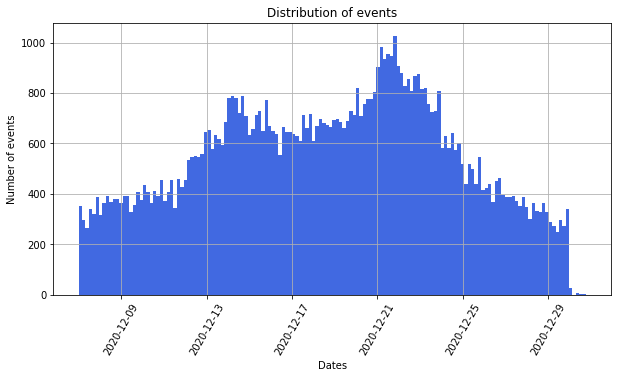

```python
#histogram by date and time
plt.figure(figsize=(10,5))
test_events['event_dt'].hist(bins=150, xrot=60, color='royalblue');
plt.title('Distribution of events');
plt.xlabel('Dates');
plt.ylabel('Number of events');
```

There is a gradual rise in event amout until Dec 13th. This makes sense- this is the recruitment period.  
After that, the events reach a peak at around Dec 21.  
According to the EU events calendar, the site launched the Christmas&New Year Promo on Dec 25th. We should expect a rise in events after that date. Nevertheless, the amount of events drops drastically (back to recruitment period numbers).  
This can be explained by holiday season- people don't actually shop on the holiday itself. The promo should have started before Christmas and not on the day of.

```python
calendar_eu
```

|  | name | regions | start_dt | finish_dt |
| --- | --- | --- | --- | --- |
| 0 | Christmas&New Year Promo | EU, N.America | 2020-12-25 | 2021-01-03 |
| 1 | St. Valentine's Day Giveaway | EU, CIS, APAC, N.America | 2020-02-14 | 2020-02-16 |
| 2 | St. Patric's Day Promo | EU, N.America | 2020-03-17 | 2020-03-19 |
| 3 | Easter Promo | EU, CIS, APAC, N.America | 2020-04-12 | 2020-04-19 |
| 5 | Black Friday Ads Campaign | EU, CIS, APAC, N.America | 2020-11-26 | 2020-12-01 |
| 7 | Labor day (May 1st) Ads Campaign | EU, CIS, APAC | 2020-05-01 | 2020-05-03 |
| 8 | International Women's Day Promo | EU, CIS, APAC | 2020-03-08 | 2020-03-10 |

### Comments on the data

Go back to the Table of Contents

**Are there any peculiarities in the data that you have to take into account before starting the A/B test?**

## Experiment results

Go back to the Table of Contents

```python
#creating a pivot table by groups and events
pivot = test_events.pivot_table(index='event_name', values='user_id', columns='group', aggfunc=lambda x: x.nunique()).reset_index()
pivot
```

| group | event_name | A | B |
| --- | --- | --- | --- |
| 0 | login | 5350 | 5058 |
| 1 | product_cart | 1726 | 1716 |
| 2 | product_page | 3577 | 3318 |
| 3 | purchase | 1903 | 1683 |

I will define a function that runs the z-test and can be used to test all events.

```python
#defining a function that runs the z-test
def check_hypothesis(event, alpha=0.05):
    """This function runs a z-test to check for statistical difference between the proportions.

    The input argumentsare event name to test and alpha level.
    """

    successes1 = pivot[pivot.event_name == event]['A'].iloc[0]
    successes2 = pivot[pivot.event_name == event]['B'].iloc[0]

    trials1 = test_events[test_events.group == 'A']['user_id'].nunique()
    trials2 = test_events[test_events.group == 'B']['user_id'].nunique()

    p1 = successes1/trials1

    p2 = successes2/trials2

    p_combined = (successes1 + successes2) / (trials1 + trials2)

    difference = p1 - p2

    z_value = difference / mth.sqrt(p_combined * (1 - p_combined) * (1/trials1 + 1/trials2))

    distr = st.norm(0, 1)

    p_value = (1 - distr.cdf(abs(z_value))) * 2

    print('p-value: ', p_value)

    if (p_value < alpha):
        print("Reject H0 for", event)
    else:
        print("Fail to Reject H0 for", event)

    print('')
```

Now we can run the z-test on each event:

H0 - There is a no significant difference between the proportions of the control group and the test group for checked event.

H1 - There is a significant difference between the proportions of the control group and the test group for checked event.

The significance level is set to 5% as normally used in the business industry.

```python
for i in pivot.event_name.unique():
    check_hypothesis(i, alpha=0.05)
```

```
p-value:  0.33090965942701267
Fail to Reject H0 for login

p-value:  0.07014790784441405
Fail to Reject H0 for product_cart

p-value:  0.17829662456570405
Fail to Reject H0 for product_page

p-value:  0.014023560498416465
Reject H0 for purchase
```

There is no statistically significant difference between the two groups for login, product page visits and product cart visits.  
There is, however, a difference in purchase. Group A participants made more purchases.

## Conclusion

Go back to the Table of Contents

To conclude: The test should be run again in January (after the holiday season ends) and after technical issues are fixed.

### Thank you for your attention!